# Capstone Milestone Report

Jason Fuchs

July 2015

# Introduction

This report documents the first steps in the Coursera JHU Data Science Capstone class: reading in the data, cleaning it, and performing some exploratory analysis on it. At the end of the report I have some questions for my colleagues on best ways to move forward.

# Process

First, I downloaded the three text files and wrote a sampling function, shown in the appendix, to make them smaller and more manageable. My function can take any percentage input. After some trial and error, I chose 5%, as this seemed to make the processing speed manageable.

Once I had the samples, I converted all three into a Corpus (a collection of documents) using the `tm` library, and then I used the `tm_map` function to clean them. You can see the transformations done to the corpus below.

```r
docs <- tm_map(docs, content_transformer(tolower))          # Convert to lowercase
docs <- tm_map(docs, removeNumbers)                         # Remove numbers
docs <- tm_map(docs, removePunctuation)                     # Remove punctuation
docs <- tm_map(docs, stripWhitespace)                       # Remove extra white space
#docs <- tm_map(docs, removeWords, stopwords("english"))     # Remove stop words
#docs <- tm_map(docs, stemDocument)                          # Stem words
```

We can view some of the stats on our corpus.

```r
inspect(docs)
```

```
## <<VCorpus>>
## Metadata:  corpus specific: 0, document level (indexed): 0
## Content:  documents: 3
##
## [[1]]
## <<PlainTextDocument>>
## Metadata:  7
## Content:  chars: 10024864
##
## [[2]]
## <<PlainTextDocument>>
## Metadata:  7
## Content:  chars: 9772528
##
## [[3]]
## <<PlainTextDocument>>
## Metadata:  7
## Content:  chars: 7605927
```

I’m not sure if I should be removing stopwords and stemming the corpus here. I create two other sets wherein each of these actions is performed. Any advice would be appreciated.

```r
docsNoStops <- tm_map(docs, removeWords, stopwords("english"))     # Remove stop words
docsStemmed <- tm_map(docs, stemDocument)                          # Stem words
```

We can see the most common words here, for the corpus with stopwords included.

```
##    are   have   this    was   with    you   that    for    and    the
##  24424  26358  26999  31097  35611  46263  51886  54666 120276 237971
```

We can get rid of the some of the less-frequent terms by using `removeSparseTerms`

```r
# Get rid of sparse terms
dtmSparse <- removeSparseTerms(dtm, 0.05)
freqSparse <- colSums(as.matrix(dtmSparse))
ordSparse <- order(freqSparse)
```

Here is a summary of the document-term matrix now. You can see that sparcity is low now.

```r
dtmSparse
```

```
## <<DocumentTermMatrix (documents: 3, terms: 23821)>>
## Non-/sparse entries: 71463/0
## Sparsity           : 0%
## Maximal term length: 17
## Weighting          : term frequency (tf)
```

The most frequently-appearing words are shown below in the word cloud below.

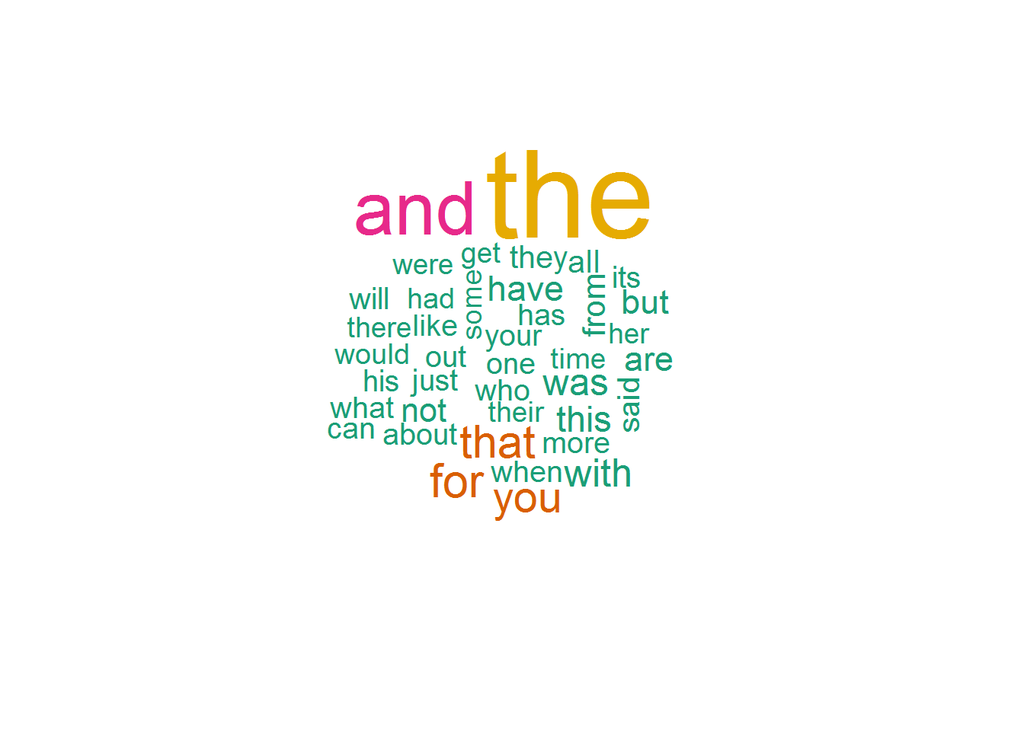

We can look at how long a typical word in the corpus is, just as a sanity check. This looks reasonable.

```
##    Min. 1st Qu.  Median    Mean 3rd Qu.    Max.
##   3.000   5.000   7.000   7.093   9.000  17.000
```

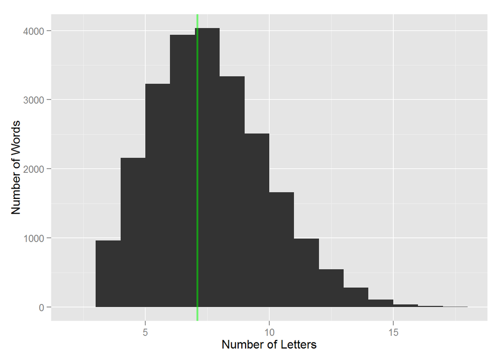

Here we can see that there are a few nonsense letters and symbols in the corpus. I found that this was even worse before I switched to reading in the texts via binary mode.

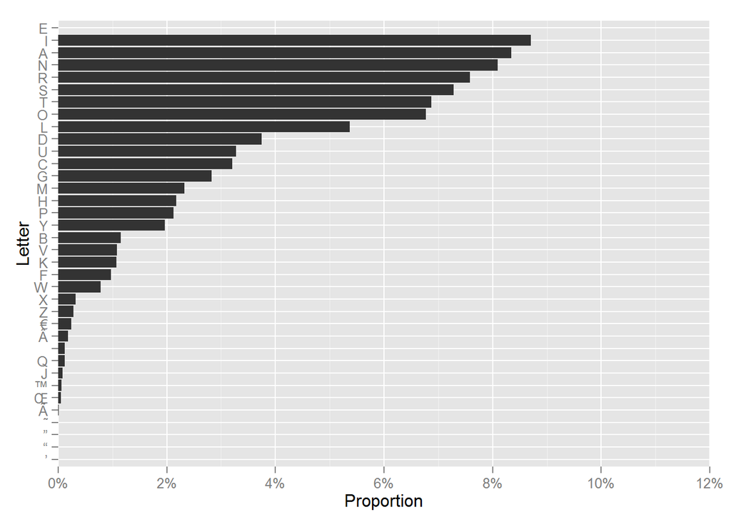

Next I found the 2-grams and 3-grams in the corpus.

You can see a few of the most frequent 2-grams

```
## with the     in a  and the   at the    to be   on the  for the   to the
##     5142     5943     6154     7231     8012     9862    10073    10758
##   in the   of the
##    20759    21640
```

Here are some of the most frequent 3-grams.

```
##    some of the       it was a     the end of      i want to     out of the
##            668            739            742            757            780
##    going to be        to be a thanks for the       a lot of     one of the
##            837            931           1177           1473           1661
```

Just for good measure, here are 2 word clouds showing the 2-grams and 3-grams.

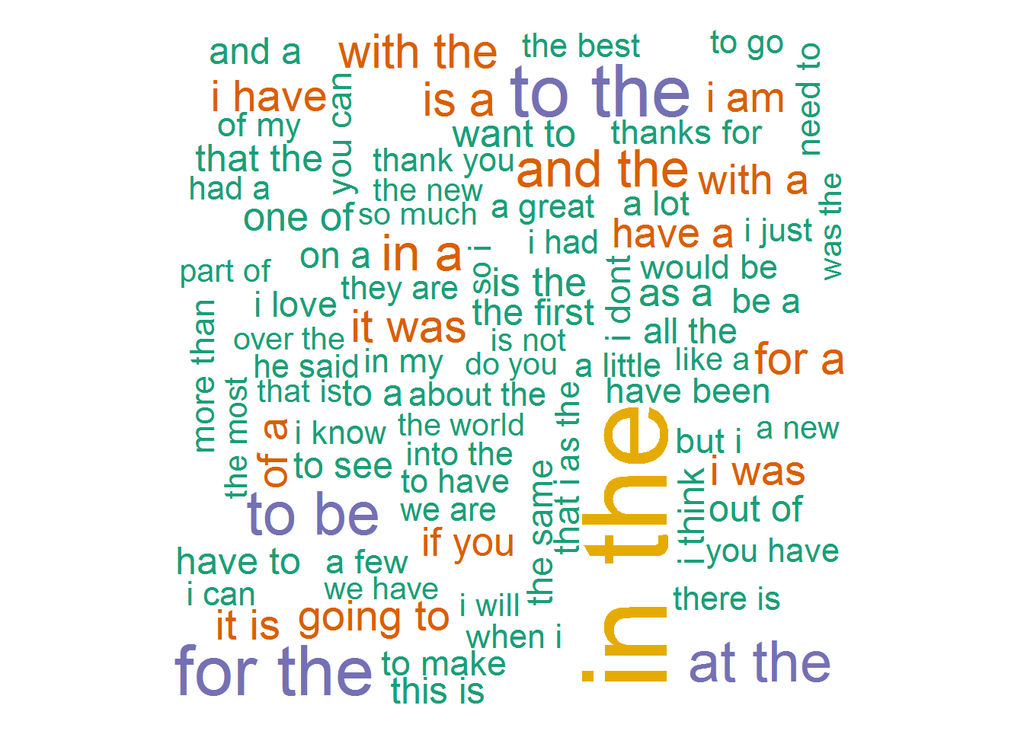

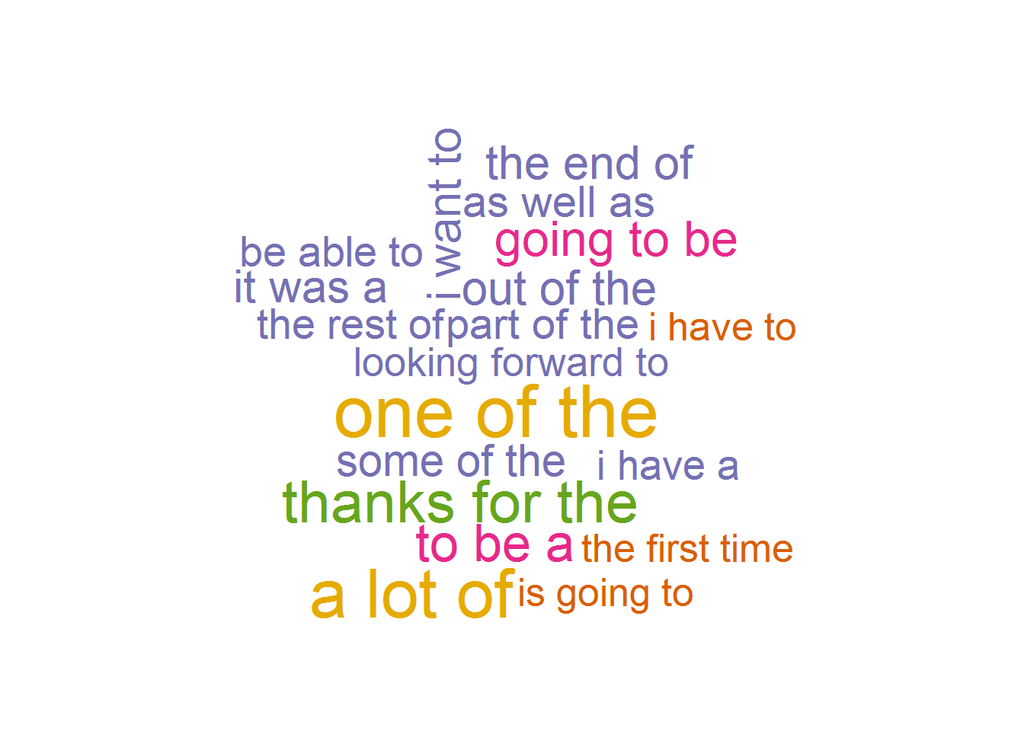

# Conclusions & Questions

From here, I will need to create my n-gram model and prediction algorithm I would like some feedback on the following:

- Is 5% a good sample to take?
- Should I remove stopwords and stem the corpus before creating a model?
- What is the best way to remove profanity? I have not done that yet.
- What is the best way to remove the strange symbols that show up in the corpus?

# Code Appendix

```r
# This function takes a file and samples some percentage of lines from it
# It creates a new file with the sampled lines only

sampleLines <- function(oldFileName, percentage, newFileName){

    # Open a new connection to the file
    con <- file(oldFileName, "rb")

    # Make sure the new file is blank
    if (file.exists(newFileName)) {
        file.remove(newFileName)
    }

    file.create(newFileName)
    numberOfLines <- 0

    # Read each line and flip a coin to decide whether to include it
    while (length(line <- readLines(con, 1, skipNul = TRUE)) > 0) {

        if (rbinom(1, 1, percentage) == 1) {
            cat(line, file = newFileName, append = TRUE, sep = "\n")
        }

        numberOfLines <- numberOfLines + 1

    }

    close(con)
    print(numberOfLines)
}

# Now apply this function to the English database

set.seed(12345)
sampleLines(oldFileName = "Coursera-SwiftKey/final/en_US/en_US.blogs.txt",
            percentage = 0.05,
            newFileName = "sample_en_US.blogs.txt")

sampleLines(oldFileName = "Coursera-SwiftKey/final/en_US/en_US.twitter.txt",
            percentage = 0.05,
            newFileName = "sample_en_US.twitter.txt")

sampleLines(oldFileName = "Coursera-SwiftKey/final/en_US/en_US.news.txt",
            percentage = 0.05,
            newFileName = "sample_en_US.news.txt")


# Look at frequencies of 2-grams and 3-grams
BigramTokenizer <- function (x) {
    NGramTokenizer(x, Weka_control(min = 2, max = 2))
}

TrigramTokenizer <- function (x) {
    NGramTokenizer(x, Weka_control(min = 3, max = 3))
}

tdm2 <- TermDocumentMatrix(docs, control = list(tokenize = BigramTokenizer))
tdm3 <- TermDocumentMatrix(docs, control = list(tokenize = TrigramTokenizer))
```